# Simulating and Estimating CTRM processes

### Simulation

We assume i.i.d. waiting times drawn from the positively skewed stable distribution with stability parameter $\beta=0.8$, scaled with $n^{-1/\beta}$. This defines a renewal process, at whose renewal times we assume i.i.d. magnitudes, drawn from a Generalized Extreme Value Distribution with shape parameter $\xi = 0.7$:

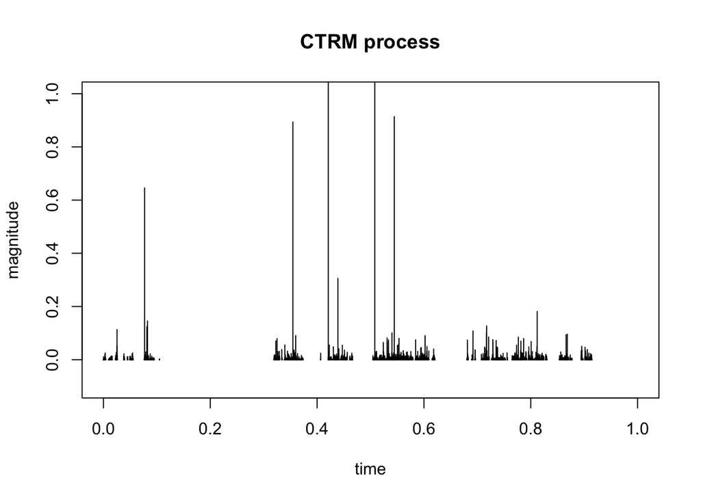

Besides the magnitude of large events, their *timing* is of interest to us. We define the exceedance time of level $\ell \in [x_0,x_F]$ as the random variable \begin{align*} T_\ell = \inf\{t: M(t) > \ell\} \end{align*} and the exceedance as \begin{align*} X_\ell = M(T_\ell) - \ell. \end{align*}

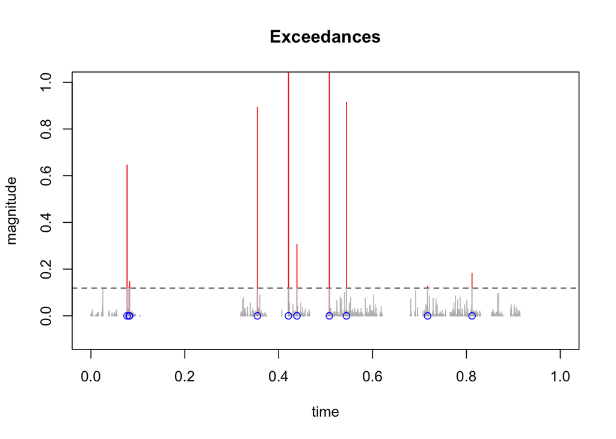

Exceedance times (blue circles) and Exceedance sizes (red lines).

### Probability distribution of Exceedance Times

#### Result by Anderson (1987)

Anderson (1987) has shown that as $\ell \uparrow x_F$ (the right end-point of the distribution of magnitudes) the following weak convergence holds:

\begin{align} \frac{T_\ell}{n(1/(1-F_J(\ell)))} \Rightarrow W_\beta. \end{align}

Here,

- $F_J(\cdot)$ is the CDF of the magnitudes $J_1, J_2, \ldots$
- $n(\cdot)$ is a norming function which varies regularly at $\infty$ with parameter $1/\beta$
- $W_\beta$ is a Mittag-Leffler random variable, defined via its Laplace transform

\begin{align} \newcommand{\ex}{\mathbf E} \ex[\exp(-\lambda W_\beta)] = \frac{1}{1 + \lambda^\beta}. \end{align}

More precisely, $n(t)$ is an asymptotic inverse to the function

\begin{align} g(t) := \frac{t}{\Gamma(2-\beta) \int_0^t(1-F_W(u))\,du} \in RV_\infty(\beta) \end{align}

#### Approach in this paper

Meerschaert and Stoev (2008) have derived a scaling limit theorem for the Continuous Time Random Maxima (CTRM) process \begin{align} M(t) = \bigvee_{k=1}^{N(t)} J_k \end{align}

where $N(t)$ is the renewal process as above: Assume that

- $\left[ \bigvee_{k=1}^{\lfloor ct \rfloor} J_k - d(c)\right] / a(c) \Rightarrow A(t)$
- $b(c)^{-1}\sum_{k=1}^{\lfloor ct \rfloor} W_k \Rightarrow D(t)$

converge (weakly in Skorokhod space) for some norming sequences $a(c)$, $d(c)$ and $b(c)$. Then

\begin{align} \frac{M(ct) - d(\tilde b(c))}{a(\tilde b(c))} \Rightarrow A(E(t)) \end{align}

where $\tilde b(c)$ is asymptotically inverse to $b(c)$ and $E(t) = \inf\{r: D(r) > t\}$ is the stochastic process inverse to $D(t)$.

For large $c$ and $t$ comparable to $c$, we may hence approximate

\begin{align} M(t) \approx a(\tilde b(c)) A(E(t/c)) + d(\tilde b(c)). \end{align}

Recalling that $c \sim b(\tilde b(c))$, may substitute $n = \tilde b(c)$ to get

\begin{align} M(t) \approx a(n) A(E(t/b(n))) + d(n). \end{align}

Then we have

\begin{align} T_\ell > t \Longleftrightarrow M(t) \le \ell \stackrel{\approx}{\Longleftrightarrow} A(E(t/b(n))) \le \frac{\ell - d(n)}{a(n)} =: \ell^* \\ \Longleftrightarrow \xi_{\ell^*} > t/b(n) \Longleftrightarrow b(n) \xi_{\ell^*} > t \end{align}

where $\xi_a := \inf\{t: A(E(t)) > a\}$ is the hitting time of level $a$ by the process $A(E(t))$. Hence we may approximate the distribution of $T_\ell$ by the distribution of the random variable $\xi_{\ell^*}$, rescaled with $b(n)$. It was shown by Meerschaert & Stoev (2008) that

$$\xi_a \stackrel{d}{=} (-\log F_A(a))^{-1/\beta} W_\beta$$

where $F_A(\cdot)$ is the CDF of $A:= A(1)$. Since

\begin{align} \bigvee_{k=1}^n J_k \le \ell \stackrel{\approx}{\Longleftrightarrow} A \le \ell^*, \end{align} we may estimate $F_A(\ell^*)$ empirically by \begin{align} \#\{k: J_k \le \ell\} / n. \end{align}

## Estimation

Assume now a time series of magnitudes, and that interest lies in the estimation of the timings of the large magnitudes. Consider a minimum threshold $\ell_0$, e.g. at the $0.9$ quantile. Vary the threshold $\ell$ on the interval $[\ell_0, x_F]$, and consider the resulting sequences of exceedance sizes and exceedance times $\{(X_{\ell,i}, T_{\ell,i})\}$. Due to the renewal property, this sequence is i.i.d., and $T_{\ell,1}, T_{\ell,2}, \ldots$ can be modelled by a Mittag-Leffler distribution.

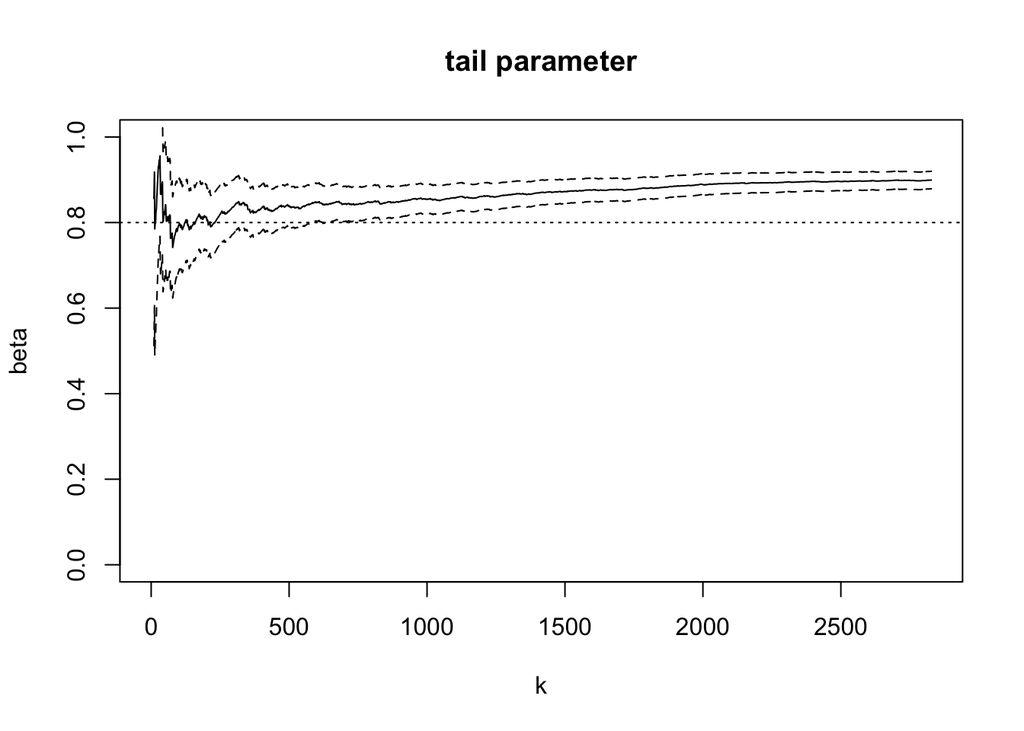

Estimate of tail parameter of Mittag Leffler distribution (y-axis), for observations thresholded at the top k observations (x-axis). The dotted line represents the correct value.

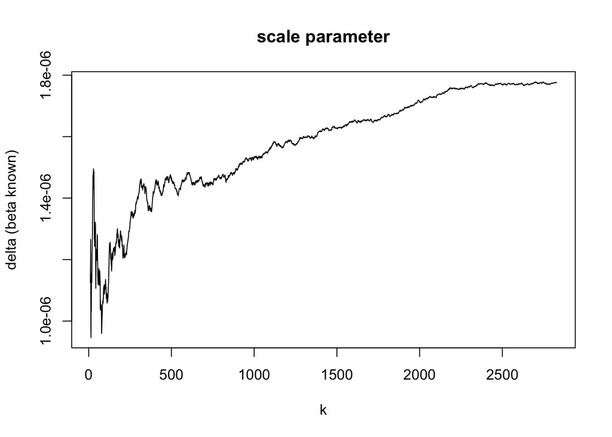

Estimate of scale parameter of Mittag Leffler distribution (y-axis), for observations thresholded at the top k observations (x-axis).

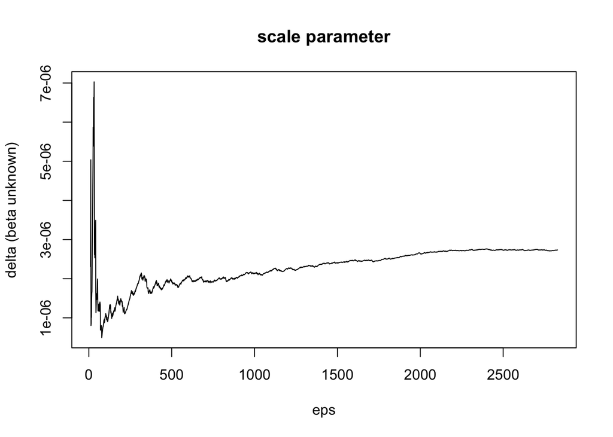

Estimate of scale parameter of Mittag Leffler distribution (y-axis), for observations thresholded at the top k observations (x-axis).